# PEGASUS targeted sphingolipids

MHuang

8/18/2020

# 1. Data assembly

## 1.1. Phenotype/EMR data

```r
load(pheno_fname, verbose = T)
```

```
## Loading objects:
##   pheno
```

## 1.2. Sphingolipids data

```r
load(sph_fname, verbose = T)
```

```
## Loading objects:
##   mets_pheno
##   mets_info
##   sph_list
##   sphoth_list
##   sm_list
##   cer_list
##   ceroth_list
```

```r
setnames(mets_pheno, c("Group", "Original_Spl_ID"), c("SampleGroup", "sampleID_biobank"))
sph_dat <- merge(pheno, mets_pheno[, c(1:which(colnames(mets_pheno) == "LacCer22_0")), with = F],
                 by = c("sampleID_biobank", "SampleGroup", "Match_ID",
                        "Asthma_Status", "Age", "Gender", "Race", "BMI", "Nonsmoker"))
sph_mets_info <- copy(mets_info)


## Add indicators for platform & without MS2

sph_mets_info[, ':='(feature = metabolite,
                     tentative_annotation = metabolite,
                     platform = "Targeted-sphingolipids",
                     wo_ms2 = 0,
                     med_feat = 0,
                     rt_min = NA,
                     mz = NA,
                     cv = NA,
                     skewness_post = skewness_met)]
# The annotations are accurate - only duplicating for programing purpose


## Remove original metabolomic data files with non-specific names

rm(mets_info, mets_pheno)
```

## 1.3. Apply exclusion

- _trim: subjects missing collection date / bmi / bmi >5yrs away from collection date & matched subjects removed
- _excl: further excluded subjects with the following comorbidities and matched subjects
  - COPD, A1AD, cystic fibrosis, bronchiectasis, chronic bronchitis, immuno deficiency

```r
stratum_to_rm <- sph_dat[is.na(Collect_Date) | is.na(bmi) | abs(bmi_timegap_y) > 5, unique(Stratum)]
stratum_to_rm <- c(stratum_to_rm, sph_dat[, .N, Stratum][N == 1, Stratum]); length(stratum_to_rm)
```

```
## [1] 39
```

```r
sph_dat_trim <- sph_dat[!(Stratum %in% stratum_to_rm), ]

comorb_excl <- sph_dat_trim[copd_5 == 1 | a1ad == 1 | cf == 1 | bronchiectasis == 1 | cbronchitis == 1 |
                                    immunodef == 1, unique(Stratum)]; length(comorb_excl)
```

```
## [1] 90
```

```r
sph_dat_excl <- sph_dat_trim[!(Stratum %in% comorb_excl), ]
```

# 2. Regression model functions

On features that passed QC with <= 30% missing

```r
feat_list <- sph_mets_info[pct_na_met <= missing_thld, feature]; length(feat_list)
```

```
## [1] 78
```

```r
clogi_res_fnc <- function(outc, mets_list, dat, mets_info, add_covar = "",
                          first_cols = c("feature", "beta", "pval", "fdr_bh", "tentative_annotation",
                                         "wo_ms2", "med_feat", "rt_min", "mz", "platform", "or",
                                         "lower95", "upper95", "totaln", "casen", "cv", "pct_na_met"),
                          na_thld = missing_thld) {

        clogi_mdl_tmp <- function(met) {

                fit <- eval(parse(text = str_c("clogit(", outc, " ~ ", met, " + strata(Stratum)",
                                               add_covar, ", data = ", dat, ")")))

                coef <- summary(fit)$coefficients
                coef <- coef[rownames(coef) == met, ]

                confint <- summary(fit)$conf.int
                confint <- confint[rownames(confint) == met, -c(1:2)]

                totaln <- summary(fit)$n
                casen <- summary(fit)$nevent

                output <- t(c(outc, met, coef, confint, totaln, casen)) %>% as.data.table()
                colnames(output) <- c("outc", "feature", "beta", "or", "se", "zval", "pval",
                                      "lower95", "upper95", "totaln", "casen")
                output[, (colnames(output)[-c(1:2)]) := lapply(.SD, as.numeric), .SDcols = colnames(output)[-c(1:2)]]

                return(output)
        }

        res <- lapply(mets_list, function(x) {clogi_mdl_tmp(met = x)}) %>% rbindlist()

        eval(parse(text = str_c("mets_info <- copy(", mets_info, ")")))
        res <- merge(res,
                     mets_info[, .(feature, rt_min, mz, tentative_annotation, wo_ms2, med_feat,
                                   platform, cv, pct_na_met, skewness_post)],
                     by = "feature")
        res[pct_na_met <= na_thld & feature != "Unknown", fdr_bh := p.adjust(pval, method = "BH")]

        setcolorder(res, first_cols)
        res <- res[order(pval)]
        return(res)
}

linreg_res_fnc <- function(expo, mets_list, dat, mets_info, add_covar = "",
                           first_cols = c("feature", "expo_linreg", "beta_linreg", "pval_linreg",
                                          "fdr_bh_linreg", "tentative_annotation", "wo_ms2", "med_feat",
                                          "rt_min", "mz", "platform", "cv", "pct_na_met"),
                           na_thld = missing_thld) {

        linear_mdl_tmp <- function(met) {

                fit <- eval(parse(text = str_c("lm(", met, " ~ ", expo, " + Age + Race",
                                               add_covar, ", data = ", dat, ")")))

                coef <- summary(fit)$coefficients
                coef <- coef[rownames(coef) == expo, ]

                output <- t(c(expo, met, coef)) %>% as.data.table()
                colnames(output) <- c("expo_linreg", "feature", "beta_linreg", "se_linreg", "tval_linreg",
                                      "pval_linreg")
                output[, (colnames(output)[-c(1:2)]) := lapply(.SD, as.numeric), .SDcols = colnames(output)[-c(1:2)]]

                return(output)
        }

        res <- lapply(mets_list, function(x) {linear_mdl_tmp(met = x)}) %>% rbindlist()

        eval(parse(text = str_c("mets_info <- copy(", mets_info, ")")))
        res <- merge(res,
                     mets_info[, .(feature, rt_min, mz, tentative_annotation, wo_ms2, med_feat,
                                   platform, cv, pct_na_met, skewness_post)],
                     by = "feature")
        res[pct_na_met <= na_thld & feature != "Unknown", fdr_bh_linreg := p.adjust(pval_linreg, method = "BH")]

        setcolorder(res, first_cols)
        res <- res[order(pval_linreg)]
        return(res)
}
```

# 3. Analyses accounting for matched strata

## 3.1. Compare excluding OCS around serum collection vs not

### 3.1.1. NOT excluding COPD, cystic fibrosis, bronchiectasis, chronic bronchitis, a1ad, immune deficiencies

```r
res_3_1_1_1 <- clogi_res_fnc(outc = "asthma_num",
                             mets_list = feat_list,
                             dat = "sph_dat_trim",
                             mets_info = "sph_mets_info",
                             add_covar = " + bmi")
# datatable(res_3_1_1_1[tentative_annotation != "Unknown"], filter = "top") %>%
#         formatSignif(columns = num_cols, digits = sig_digits)

dat_tmp <- sph_dat_trim[Stratum %in% sph_dat_trim[ocs_ard_serum_coll == 0, Stratum], ]
res_3_1_1_2 <- clogi_res_fnc(outc = "asthma_num",
                             mets_list = feat_list,
                             dat = "dat_tmp",
                             mets_info = "sph_mets_info",
                             add_covar = " + bmi")
# datatable(res_3_1_1_2[tentative_annotation != "Unknown"], filter = "top") %>%
#         formatSignif(columns = num_cols, digits = sig_digits)

res_3_1_1_1[tentative_annotation != "Unknown" & pval < alpha_thld/5, .N,
         feature %in% res_3_1_1_2[tentative_annotation != "Unknown" & pval < alpha_thld/5, feature]]
```

```
##    feature N
## 1:    TRUE 2
## 2:   FALSE 1
```

```r
res_3_1_1_2[tentative_annotation != "Unknown" & pval < alpha_thld/5, .N,
         feature %in% res_3_1_1_1[tentative_annotation != "Unknown" & pval < alpha_thld/5, feature]]
```

```
##    feature N
## 1:    TRUE 2
```

### 3.1.2. Excluding COPD, cystic fibrosis, bronchiectasis, chronic bronchitis, a1ad, immune deficiencies

```r
res_3_1_2_1 <- clogi_res_fnc(outc = "asthma_num",
                             mets_list = feat_list,
                             dat = "sph_dat_excl",
                             mets_info = "sph_mets_info",
                             add_covar = " + bmi")
# datatable(res_3_1_2_1[tentative_annotation != "Unknown"], filter = "top") %>%
#         formatSignif(columns = num_cols, digits = sig_digits)

dat_tmp <- sph_dat_excl[Stratum %in% sph_dat_excl[ocs_ard_serum_coll == 0, Stratum], ]
res_3_1_2_2 <- clogi_res_fnc(outc = "asthma_num",
                             mets_list = feat_list,
                             dat = "dat_tmp",
                             mets_info = "sph_mets_info",
                             add_covar = " + bmi")
# datatable(res_3_1_2_2[tentative_annotation != "Unknown"], filter = "top") %>%
#         formatSignif(columns = num_cols, digits = sig_digits)

res_3_1_2_1[tentative_annotation != "Unknown" & pval < alpha_thld/5, .N,
         feature %in% res_3_1_2_2[tentative_annotation != "Unknown" & pval < alpha_thld/5, feature]]
```

```
##    feature N
## 1:    TRUE 2
```

```r
res_3_1_2_2[tentative_annotation != "Unknown" & pval < alpha_thld/5, .N,
         feature %in% res_3_1_2_1[tentative_annotation != "Unknown" & pval < alpha_thld/5, feature]]
```

```
##    feature N
## 1:   FALSE 2
## 2:    TRUE 2
```

> Conclusion: excluding asthmatics with OCS within 10 days of serum collection made a small amount of differences in the number of annotated metabolites with p<0.01; will proceed without the exclusion

## 3.2. Compare excluding certain comorbidities vs not

Comorbidities excluded here: COPD, cystic fibrosis, bronchiectasis, chronic bronchitis, a1ad, immune deficiencies

```r
res_3_1_1_1[tentative_annotation != "Unknown" & pval < alpha_thld/5, .N,
         feature %in% res_3_1_2_1[tentative_annotation != "Unknown" & pval < alpha_thld/5, feature]]
```

```
##    feature N
## 1:    TRUE 2
## 2:   FALSE 1
```

```r
res_3_1_2_1[tentative_annotation != "Unknown" & pval < alpha_thld/5, .N,
         feature %in% res_3_1_1_1[tentative_annotation != "Unknown" & pval < alpha_thld/5, feature]]
```

```
##    feature N
## 1:    TRUE 2
```

```r
datatable(res_3_1_1_1[tentative_annotation != "Unknown"], filter = "top") %>%
        formatSignif(columns = num_cols, digits = sig_digits)
```

|  | feature | beta | pval | fdr_bh | tentative_annotation | wo_ms2 | med_feat | rt_min | mz | platform | or | lower95 | upper95 | totaln | casen | cv | pct_na_met | outc | se | zval | skewness_post |
| --- | --- | --- | --- | --- | --- | --- | --- | --- | --- | --- | --- | --- | --- | --- | --- | --- | --- | --- | --- | --- | --- |
| 1 | S1Pd18_1 | 0.0017546212351573 | 0.000362204280339882 | 0.0282519338665108 | S1Pd18_1 | 0 | 0 |  |  | Targeted-sphingolipids | 1.00175616148372 | 1.0007906015598 | 1.0027226529771 | 1062 | 531 |  | 0 | asthma_num | 0.00049201518178732 | 3.56619328042555 | 0.0147170159157704 |
| 2 | Spa1Pd18_0 | 0.00459133934910383 | 0.000951112797422838 | 0.0370933990994907 | Spa1Pd18_0 | 0 | 0 |  |  | Targeted-sphingolipids | 1.00460189569736 | 1.00186995606108 | 1.00734128489745 | 1062 | 531 |  | 0 | asthma_num | 0.0013893773053042 | 3.30460223553067 | 0.374011490565191 |
| 3 | Sph18_1 | 0.0270440062996385 | 0.00517189946214928 | 0.134469386015881 | Sph18_1 | 0 | 0 |  |  | Targeted-sphingolipids | 1.02741301441365 | 1.00812012270589 | 1.04707512369981 | 1062 | 531 |  | 0 | asthma_num | 0.00967195037715583 | 2.79612748670772 | 1.97611301434023 |
| 4 | Cer1P24_1 | -0.026303974472386 | 0.0234441638592158 | 0.290561283847631 | Cer1P24_1 | 0 | 0 |  |  | Targeted-sphingolipids | 0.974038961623912 | 0.952129460408474 | 0.99645262352702 | 1062 | 531 |  | 0 | asthma_num | 0.0116075046885124 | -2.2661179278625 | 1.22971032674779 |
| 5 | Spad18_0 | 0.0556351551129241 | 0.0250367897900225 | 0.290561283847631 | Spad18_0 | 0 | 0 |  |  | Targeted-sphingolipids | 1.05721189500992 | 1.00699779100594 | 1.10992993324636 | 1061 | 531 |  | 0.00087719298245614 | asthma_num | 0.0248278720432253 | 2.24083461587297 | 1.61768632959789 |
| 6 | Cer1P24_0 | -0.00880018804988346 | 0.0286022591633816 | 0.290561283847631 | Cer1P24_0 | 0 | 0 |  |  | Targeted-sphingolipids | 0.99123842026848 | 0.983458461932297 | 0.999079924418804 | 1062 | 531 |  | 0 | asthma_num | 0.00402032333323381 | -2.18892544714927 | 0.884915535814656 |
| 7 | Cer18_0d18_1 | 0.00244207085738015 | 0.0371994850849967 | 0.290561283847631 | Cer18_0d18_1 | 0 | 0 |  |  | Targeted-sphingolipids | 1.0024450551412 | 1.00014488200494 | 1.00475051830749 | 1062 | 531 |  | 0 | asthma_num | 0.00117206201998929 | 2.08356794754125 | 1.34861703337603 |
| 8 | HexCer24_0 | 0.216235440246415 | 0.0388943812817501 | 0.290561283847631 | HexCer24_0 | 0 | 0 |  |  | Targeted-sphingolipids | 1.24139461885177 | 1.01108990253793 | 1.52415783784006 | 1062 | 531 |  | 0 | asthma_num | 0.104699158459235 | 2.06530256239459 | 1.95056520028347 |
| 9 | Sphd18_2 | 1.35596631575725 | 0.0392920813269992 | 0.290561283847631 | Sphd18_2 | 0 | 0 |  |  | Targeted-sphingolipids | 3.88050894240989 | 1.06880922558785 | 14.088903137827 | 1062 | 531 |  | 0 | asthma_num | 0.657880027612696 | 2.06111488241672 | 1.96532175099432 |
| 10 | SM24_0d18_2 | -2.33446720960468e-05 | 0.0393498722641406 | 0.290561283847631 | SM24_0d18_2 | 0 | 0 |  |  | Targeted-sphingolipids | 0.999976655600389 | 0.999954450828409 | 0.999998860865443 | 1062 | 531 |  | 0 | asthma_num | 1.13295637396296e-05 | -2.06050935698342 | 0.687374497674353 |

[output cut: 68 more lines]

```r
datatable(res_3_1_2_1[tentative_annotation != "Unknown"], filter = "top") %>%
        formatSignif(columns = num_cols, digits = sig_digits)
```

|  | feature | beta | pval | fdr_bh | tentative_annotation | wo_ms2 | med_feat | rt_min | mz | platform | or | lower95 | upper95 | totaln | casen | cv | pct_na_met | outc | se | zval | skewness_post |
| --- | --- | --- | --- | --- | --- | --- | --- | --- | --- | --- | --- | --- | --- | --- | --- | --- | --- | --- | --- | --- | --- |
| 1 | S1Pd18_1 | 0.00169408942356894 | 0.00151672437537099 | 0.118304501278937 | S1Pd18_1 | 0 | 0 |  |  | Targeted-sphingolipids | 1.00169552520372 | 1.00064735215624 | 1.00274479620718 | 882 | 441 |  | 0 | asthma_num | 0.000534166299796419 | 3.17146443760041 | 0.0147170159157704 |
| 2 | Spa1Pd18_0 | 0.00430774454343292 | 0.00375958085545033 | 0.146623653362563 | Spa1Pd18_0 | 0 | 0 |  |  | Targeted-sphingolipids | 1.00431703621221 | 1.00139497775197 | 1.00724762120378 | 882 | 441 |  | 0 | asthma_num | 0.00148662878093742 | 2.89765985878236 | 0.374011490565191 |
| 3 | Cer20_1d18_1 | -0.0390490752356744 | 0.0202024316292628 | 0.400775007445174 | Cer20_1d18_1 | 0 | 0 |  |  | Targeted-sphingolipids | 0.961703512161766 | 0.930529271371957 | 0.993922140612147 | 882 | 441 |  | 0 | asthma_num | 0.0168128959195656 | -2.32256688095191 | 1.31451332341385 |
| 4 | S1Pd18_2 | 0.0051030239875404 | 0.0205525644843679 | 0.400775007445174 | S1Pd18_2 | 0 | 0 |  |  | Targeted-sphingolipids | 1.00511606659058 | 1.0007849847659 | 1.00946589197163 | 882 | 441 |  | 0 | asthma_num | 0.00220327883323568 | 2.31610448508064 | 0.588777423390448 |
| 5 | Cer18_1d18_1 | -0.06516371503 | 0.0310184604764391 | 0.48388798343245 | Cer18_1d18_1 | 0 | 0 |  |  | Targeted-sphingolipids | 0.936914063906767 | 0.88304473983141 | 0.994069636057039 | 882 | 441 |  | 0 | asthma_num | 0.0302126452899644 | -2.15683580185033 | 1.21569901494386 |
| 6 | Sph18_1 | 0.0203626283006264 | 0.0480994523116629 | 0.564920034963736 | Sph18_1 | 0 | 0 |  |  | Targeted-sphingolipids | 1.02057136099097 | 1.00017025932974 | 1.04138859675048 | 882 | 441 |  | 0 | asthma_num | 0.0103024257703912 | 1.97648871774916 | 1.97611301434023 |
| 7 | SM14_d18_1 | -9.52741189957802e-05 | 0.0506979518557199 | 0.564920034963736 | SM14_d18_1 | 0 | 0 |  |  | Targeted-sphingolipids | 0.999904730419439 | 0.999809180525783 | 1.00000028944462 | 882 | 441 |  | 0 | asthma_num | 4.87578161267603e-05 | -1.95402761165691 | 0.747642841551744 |
| 8 | X3_KS | 0.0538310915031219 | 0.0659800243950429 | 0.568705308556636 | X3_KS | 0 | 0 |  |  | Targeted-sphingolipids | 1.05530633689313 | 0.996451709711209 | 1.11763716578857 | 882 | 441 |  | 0 | asthma_num | 0.0292789522448956 | 1.83855935324689 | 4.69190864162666 |
| 9 | Cer1P24_1 | -0.0222923518358103 | 0.0747403199836255 | 0.568705308556636 | Cer1P24_1 | 0 | 0 |  |  | Targeted-sphingolipids | 0.977954286523455 | 0.95426846770251 | 1.00222800909707 | 882 | 441 |  | 0 | asthma_num | 0.0125093536383769 | -1.78205465128275 | 1.22971032674779 |
| 10 | DhCer24_1 | 0.00328558357411163 | 0.0840381890684985 | 0.568705308556636 | DhCer24_1 | 0 | 0 |  |  | Targeted-sphingolipids | 1.00329098702003 | 0.999558444996373 | 1.00703746706804 | 882 | 441 |  | 0 | asthma_num | 0.00190168601119987 | 1.72772137711556 | 1.94067181409354 |

[output cut: 68 more lines]

> Conclusion: will proceed with excluding these conditions (res_3_1_2_1)

## 3.3. Adjusted for BMI & certain comorbities

Excluding COPD, cystic fibrosis, bronchiectasis, chronic bronchitis, alpha-1-antitrypsin deficiency, and immune deficiencies Adjusting for pulmonary hypertension, allergic rhinitis, congestive heart failure, gerd

```r
res_3_3 <- clogi_res_fnc(outc = "asthma_num",
                         mets_list = feat_list,
                         dat = "sph_dat_excl",
                         mets_info = "sph_mets_info",
                         add_covar = " + bmi + pulhtn + arhinitis + chf + gerd")

res_3_1_2_1[tentative_annotation != "Unknown" & pval < alpha_thld/5, .N,
         feature %in% res_3_3[tentative_annotation != "Unknown" & pval < alpha_thld/5, feature]]
```

```
##    feature N
## 1:   FALSE 2
```

```r
res_3_3[tentative_annotation != "Unknown" & pval < alpha_thld/5, .N,
         feature %in% res_3_1_2_1[tentative_annotation != "Unknown" & pval < alpha_thld/5, feature]]
```

```
##    feature N
## 1:   FALSE 2
```

> Conclusion: will proceed with not adjusting for pulmonary hypertension, allergic rhinitis, congestive heart failure, gerd

# 4. Association with ICS # prescriptions in all asthmatics

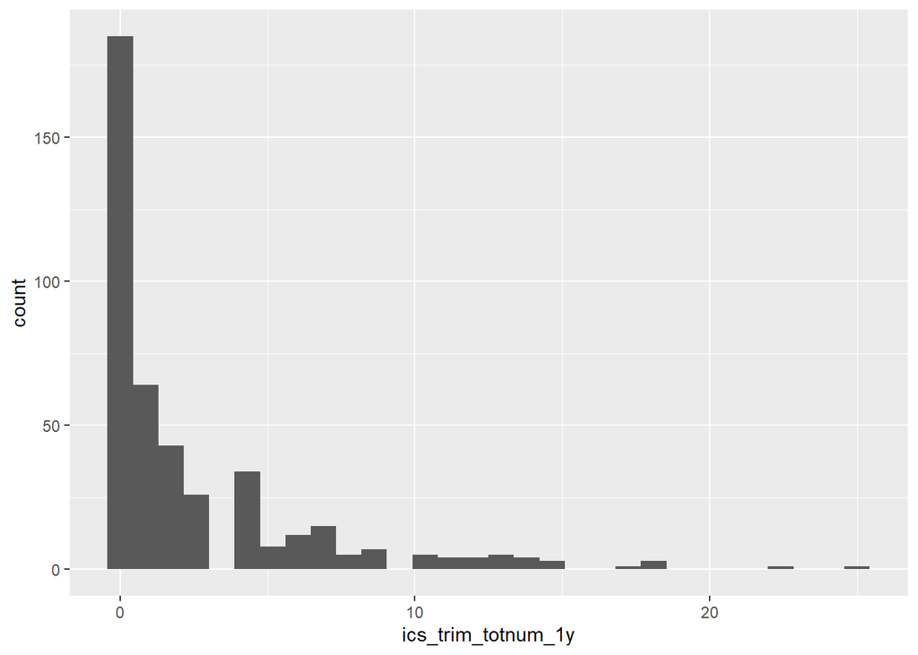

```r
dat_tmp <- sph_dat_excl[asthma_num == 1, ]
ggplot(dat_tmp) + geom_histogram(aes(ics_trim_totnum_1y), bins = 30)
```

```r
# dat_tmp[, ics_trim_totnum_1y_ind := case_when(ics_trim_totnum_1y == 0 ~ 0,
#                                               ics_trim_totnum_1y > 1 ~ 1)]
res_ics <- linreg_res_fnc(expo = "ics_trim_totnum_1y",
                          mets_list = feat_list,
                          dat = "dat_tmp",
                          mets_info = "sph_mets_info",
                          add_covar = " + Gender + bmi")

res_overall <- merge(res_3_1_2_1,
                     res_ics[, .(feature, expo_linreg, beta_linreg, pval_linreg, fdr_bh_linreg)],
                     by = "feature")
res_overall <- res_overall[order(pval)][, subgroup := "overall"] %>% setcolorder(., "subgroup")

display_cols <- c("subgroup", "feature", "tentative_annotation", "med_feat", "platform", "beta", "pval", "fdr_bh",
                  "or", "lower95", "upper95", "expo_linreg", "beta_linreg", "pval_linreg", "fdr_bh_linreg")
datatable(res_overall[tentative_annotation != "Unknown", ..display_cols], filter = "top") %>%
        formatSignif(columns = c("beta", "pval", "fdr_bh", "or", "lower95", "upper95",
                                 "beta_linreg", "pval_linreg", "fdr_bh_linreg"), digits = sig_digits)
```

|  | subgroup | feature | tentative_annotation | med_feat | platform | beta | pval | fdr_bh | or | lower95 | upper95 | expo_linreg | beta_linreg | pval_linreg | fdr_bh_linreg |
| --- | --- | --- | --- | --- | --- | --- | --- | --- | --- | --- | --- | --- | --- | --- | --- |
| 1 | overall | S1Pd18_1 | S1Pd18_1 | 0 | Targeted-sphingolipids | 0.00169408942356894 | 0.00151672437537099 | 0.118304501278937 | 1.00169552520372 | 1.00064735215624 | 1.00274479620718 | ics_trim_totnum_1y | -0.10235309827115 | 0.948538183542371 | 0.999751519698199 |
| 2 | overall | Spa1Pd18_0 | Spa1Pd18_0 | 0 | Targeted-sphingolipids | 0.00430774454343292 | 0.00375958085545033 | 0.146623653362563 | 1.00431703621221 | 1.00139497775197 | 1.00724762120378 | ics_trim_totnum_1y | 0.0726277102831617 | 0.902231353345352 | 0.999751519698199 |
| 3 | overall | Cer20_1d18_1 | Cer20_1d18_1 | 0 | Targeted-sphingolipids | -0.0390490752356744 | 0.0202024316292628 | 0.400775007445174 | 0.961703512161766 | 0.930529271371957 | 0.993922140612147 | ics_trim_totnum_1y | 0.027139830998901 | 0.582817649754645 | 0.999751519698199 |
| 4 | overall | S1Pd18_2 | S1Pd18_2 | 0 | Targeted-sphingolipids | 0.0051030239875404 | 0.0205525644843679 | 0.400775007445174 | 1.00511606659058 | 1.0007849847659 | 1.00946589197163 | ics_trim_totnum_1y | 0.209035684873399 | 0.598785081721057 | 0.999751519698199 |
| 5 | overall | Cer18_1d18_1 | Cer18_1d18_1 | 0 | Targeted-sphingolipids | -0.06516371503 | 0.0310184604764391 | 0.48388798343245 | 0.936914063906767 | 0.88304473983141 | 0.994069636057039 | ics_trim_totnum_1y | 0.04089087845136 | 0.129780420268625 | 0.999751519698199 |
| 6 | overall | Sph18_1 | Sph18_1 | 0 | Targeted-sphingolipids | 0.0203626283006264 | 0.0480994523116629 | 0.564920034963736 | 1.02057136099097 | 1.00017025932974 | 1.04138859675048 | ics_trim_totnum_1y | -0.0109195400152924 | 0.912017689787181 | 0.999751519698199 |
| 7 | overall | SM14_d18_1 | SM14_d18_1 | 0 | Targeted-sphingolipids | -9.52741189957802e-05 | 0.0506979518557199 | 0.564920034963736 | 0.999904730419439 | 0.999809180525783 | 1.00000028944462 | ics_trim_totnum_1y | -0.558150091718879 | 0.975278355279519 | 0.999751519698199 |
| 8 | overall | X3_KS | X3_KS | 0 | Targeted-sphingolipids | 0.0538310915031219 | 0.0659800243950429 | 0.568705308556636 | 1.05530633689313 | 0.996451709711209 | 1.11763716578857 | ics_trim_totnum_1y | 0.0389570648745533 | 0.231276861865063 | 0.999751519698199 |
| 9 | overall | Cer1P24_1 | Cer1P24_1 | 0 | Targeted-sphingolipids | -0.0222923518358103 | 0.0747403199836255 | 0.568705308556636 | 0.977954286523455 | 0.95426846770251 | 1.00222800909707 | ics_trim_totnum_1y | -0.0461294821874368 | 0.536324300609207 | 0.999751519698199 |
| 10 | overall | DhCer24_1 | DhCer24_1 | 0 | Targeted-sphingolipids | 0.00328558357411163 | 0.0840381890684985 | 0.568705308556636 | 1.00329098702003 | 0.999558444996373 | 1.00703746706804 | ics_trim_totnum_1y | 0.304574077862789 | 0.553209109082394 | 0.999751519698199 |

[output cut: 68 more lines]

```r
## Save results

saveRDS(res_overall, file = here(res_dir, "res_overall_sph.rds"))
```

# 5. Subgroup analyses

## 5.1. Subgroup by gender

### 5.1.1. Female

```r
## Asthmatics vs controls

dat_tmp1 <- sph_dat_excl[Gender == "F", ]
res_5_1_1 <- clogi_res_fnc(outc = "asthma_num",
                           mets_list = feat_list,
                           dat = "dat_tmp1",
                           mets_info = "sph_mets_info",
                           add_covar = " + bmi")
res_5_1_1[tentative_annotation != "Unknown" & pval < alpha_thld/5, .N,
          feature %in% res_overall[tentative_annotation != "Unknown" & pval < alpha_thld/5, feature]]
```

```
##    feature N
## 1:   FALSE 2
```

```r
res_5_1_1 <- res_5_1_1[, subgroup := "female"] %>% setcolorder(., "subgroup")


## Association with ICS # prescription in asthmatics

dat_tmp2 <- sph_dat_excl[Gender == "F" & asthma_num == 1, ]
res_5_1_1_ics <- linreg_res_fnc(expo = "ics_trim_totnum_1y",
                                mets_list = feat_list,
                                dat = "dat_tmp2",
                                mets_info = "sph_mets_info",
                                add_covar = " + bmi")
res_female <- merge(res_5_1_1,
                    res_5_1_1_ics[, .(feature, expo_linreg, beta_linreg, pval_linreg, fdr_bh_linreg)],
                    by = "feature")


## Save results

saveRDS(res_female, file = here(res_dir, "res_female_sph.rds"))
```

### 5.1.2. Male

```r
## Asthmatics vs controls

dat_tmp1 <- sph_dat_excl[Gender == 'M', ]
res_5_1_2 <- clogi_res_fnc(outc = "asthma_num",
                           mets_list = feat_list,
                           dat = "dat_tmp1",
                           mets_info = "sph_mets_info",
                           add_covar = " + bmi")
res_5_1_2[tentative_annotation != "Unknown" & pval < alpha_thld/5, .N,
          feature %in% res_3_1_2_1[tentative_annotation != "Unknown" & pval < alpha_thld/5, feature]]
```

```
##    feature N
## 1:    TRUE 2
## 2:   FALSE 1
```

```r
res_5_1_2 <- res_5_1_2[, subgroup := "male"] %>% setcolorder(., "subgroup")


## Association with ICS # prescription in asthmatics

dat_tmp2 <- sph_dat_excl[Gender == "M" & asthma_num == 1, ]
res_5_1_2_ics <- linreg_res_fnc(expo = "ics_trim_totnum_1y",
                                mets_list = feat_list,
                                dat = "dat_tmp2",
                                mets_info = "sph_mets_info",
                                add_covar = " + bmi")
res_male <- merge(res_5_1_2,
                  res_5_1_2_ics[, .(feature, expo_linreg, beta_linreg, pval_linreg, fdr_bh_linreg)],
                  by = "feature")


## Save results

saveRDS(res_male, file = here(res_dir, "res_male_sph.rds"))
```

## 5.2. Subgroup by ICS use in 1 year before collection

### 5.2.1. ICS # prescription > 0

```r
## Asthmatics vs controls

dat_tmp1 <- sph_dat_excl[Stratum %in% sph_dat_excl[asthma_num == 1 & ics_trim_totnum_1y > 0, Stratum], ]
res_5_2_1 <- clogi_res_fnc(outc = "asthma_num",
                           mets_list = feat_list,
                           dat = "dat_tmp1",
                           mets_info = "sph_mets_info",
                           add_covar = " + bmi")
res_5_2_1[tentative_annotation != "Unknown" & pval < alpha_thld/5, .N,
          feature %in% res_overall[tentative_annotation != "Unknown" & pval < alpha_thld/5, feature]]
```

```
##    feature N
## 1:    TRUE 2
```

```r
res_5_2_1 <- res_5_2_1[, subgroup := "ics_1y_prior_yes"] %>% setcolorder(., "subgroup")


## Association with ICS # prescription in asthmatics

dat_tmp2 <- sph_dat_excl[ics_trim_totnum_1y > 0 & asthma_num == 1, ]
res_5_2_1_ics <- linreg_res_fnc(expo = "ics_trim_totnum_1y",
                                mets_list = feat_list,
                                dat = "dat_tmp2",
                                mets_info = "sph_mets_info",
                                add_covar = " + Gender + bmi")
res_ics_1y_y <- merge(res_5_2_1,
                      res_5_2_1_ics[, .(feature, expo_linreg, beta_linreg, pval_linreg, fdr_bh_linreg)],
                      by = "feature")


## Save results

saveRDS(res_ics_1y_y, file = here(res_dir, "res_ics_1y_y_sph.rds"))
```

### 5.2.2. ICS # prescription == 0

```r
## Asthmatics vs controls

dat_tmp1 <- sph_dat_excl[Stratum %in% sph_dat_excl[asthma_num == 1 & ics_trim_totnum_1y == 0, Stratum], ]
res_5_2_2 <- clogi_res_fnc(outc = "asthma_num",
                           mets_list = feat_list,
                           dat = "dat_tmp1",
                           mets_info = "sph_mets_info",
                           add_covar = " + bmi")
res_5_2_2[tentative_annotation != "Unknown" & pval < alpha_thld/5, .N,
          feature %in% res_overall[tentative_annotation != "Unknown" & pval < alpha_thld/5, feature]]
```

```
## Empty data.table (0 rows and 2 cols): feature,N
```

```r
res_5_2_2 <- res_5_2_2[, subgroup := "ics_1y_prior_no"] %>% setcolorder(., "subgroup")


## Save results

res_ics_1y_n <- res_5_2_2[, ':='(expo_linreg = NA, beta_linreg = NA, pval_linreg = NA, fdr_bh_linreg = NA)]
saveRDS(res_ics_1y_n, file = here(res_dir, "res_ics_1y_n_sph.rds"))
```

## 5.3. Subgroup by eosinophil count

### 5.3.1. EOS >= 0.3 K/uL

```r
## Asthmatics vs controls

dat_tmp1 <- sph_dat_excl[Stratum %in% sph_dat_excl[asthma_num == 1 & eos >= 0.3, Stratum], ]
res_5_3_1 <- clogi_res_fnc(outc = "asthma_num",
                           mets_list = feat_list,
                           dat = "dat_tmp1",
                           mets_info = "sph_mets_info",
                           add_covar = " + bmi")
res_5_3_1[tentative_annotation != "Unknown" & pval < alpha_thld/5, .N,
          feature %in% res_overall[tentative_annotation != "Unknown" & pval < alpha_thld/5, feature]]
```

```
##    feature N
## 1:    TRUE 1
## 2:   FALSE 2
```

```r
res_5_3_1 <- res_5_3_1[, subgroup := "eos_high_300"] %>% setcolorder(., "subgroup")


## Association with ICS # prescription in asthmatics

dat_tmp2 <- sph_dat_excl[asthma_num == 1 & eos >= 0.3, ]
res_5_3_1_ics <- linreg_res_fnc(expo = "ics_trim_totnum_1y",
                                mets_list = feat_list,
                                dat = "dat_tmp2",
                                mets_info = "sph_mets_info",
                                add_covar = " + Gender + bmi")
res_eos_high <- merge(res_5_3_1,
                      res_5_3_1_ics[, .(feature, expo_linreg, beta_linreg, pval_linreg, fdr_bh_linreg)],
                      by = "feature")


## Save results

saveRDS(res_eos_high, file = here(res_dir, "res_eos_high_sph.rds"))
```

### 5.3.2. EOS < 0.3 K/uL

```r
## Asthmatics vs controls

dat_tmp1 <- sph_dat_excl[Stratum %in% sph_dat_excl[asthma_num == 1 & eos < 0.3, Stratum], ]
res_5_3_2 <- clogi_res_fnc(outc = "asthma_num",
                           mets_list = feat_list,
                           dat = "dat_tmp1",
                           mets_info = "sph_mets_info",
                           add_covar = " + bmi")
res_5_3_2[tentative_annotation != "Unknown" & pval < alpha_thld/5, .N,
          feature %in% res_overall[tentative_annotation != "Unknown" & pval < alpha_thld/5, feature]]
```

```
## Empty data.table (0 rows and 2 cols): feature,N
```

```r
res_5_3_2 <- res_5_3_2[, subgroup := "eos_low_300"] %>% setcolorder(., "subgroup")


## Association with ICS # prescription in asthmatics

dat_tmp2 <- sph_dat_excl[asthma_num == 1 & eos < 0.3, ]
res_5_3_2_ics <- linreg_res_fnc(expo = "ics_trim_totnum_1y",
                                mets_list = feat_list,
                                dat = "dat_tmp2",
                                mets_info = "sph_mets_info",
                                add_covar = " + Gender + bmi")
res_eos_low <- merge(res_5_3_2,
                     res_5_3_2_ics[, .(feature, expo_linreg, beta_linreg, pval_linreg, fdr_bh_linreg)],
                     by = "feature")


## Save results

saveRDS(res_eos_low, file = here(res_dir, "res_eos_low_sph.rds"))
```

## 5.4. Subgroup by asthma exacerbation == 0 in 1 year before collection

### 5.4.1. Exacerbation count > 0

```r
## Asthmatics vs controls

dat_tmp1 <- sph_dat_excl[Stratum %in% sph_dat_excl[asthma_num == 1 &
                                                                 asthma_exacerbation_trim_totnum_1y > 0, Stratum], ]
res_5_4_1 <- clogi_res_fnc(outc = "asthma_num",
                           mets_list = feat_list,
                           dat = "dat_tmp1",
                           mets_info = "sph_mets_info",
                           add_covar = " + bmi")
res_5_4_1[tentative_annotation != "Unknown" & pval < alpha_thld/5, .N,
          feature %in% res_overall[tentative_annotation != "Unknown" & pval < alpha_thld/5, feature]]
```

```
## Empty data.table (0 rows and 2 cols): feature,N
```

```r
res_5_4_1 <- res_5_4_1[, subgroup := "exacerbation_1y_prior_yes"] %>% setcolorder(., "subgroup")


## Association with ICS # prescription in asthmatics

dat_tmp2 <- sph_dat_excl[asthma_num == 1 & asthma_exacerbation_trim_totnum_1y > 0, ]
res_5_4_1_ics <- linreg_res_fnc(expo = "ics_trim_totnum_1y",
                                mets_list = feat_list,
                                dat = "dat_tmp2",
                                mets_info = "sph_mets_info",
                                add_covar = " + Gender + bmi")
res_exac_1y_y <- merge(res_5_4_1,
                       res_5_4_1_ics[, .(feature, expo_linreg, beta_linreg, pval_linreg, fdr_bh_linreg)],
                       by = "feature")


## Save results

saveRDS(res_exac_1y_y, file = here(res_dir, "res_exac_1y_y_sph.rds"))
```

### 5.4.2. Exacerbation count == 0

```r
## Asthmatics vs controls

dat_tmp1 <- sph_dat_excl[Stratum %in% sph_dat_excl[asthma_num == 1 &
                                                                 asthma_exacerbation_trim_totnum_1y == 0, Stratum], ]
res_5_4_2 <- clogi_res_fnc(outc = "asthma_num",
                           mets_list = feat_list,
                           dat = "dat_tmp1",
                           mets_info = "sph_mets_info",
                           add_covar = " + bmi")
res_5_4_2[tentative_annotation != "Unknown" & pval < alpha_thld/5, .N,
          feature %in% res_overall[tentative_annotation != "Unknown" & pval < alpha_thld/5, feature]]
```

```
##    feature N
## 1:   FALSE 1
```

```r
res_5_4_2 <- res_5_4_2[, subgroup := "exacerbation_1y_prior_no"] %>% setcolorder(., "subgroup")


## Association with ICS # prescription in asthmatics

dat_tmp2 <- sph_dat_excl[asthma_num == 1 & asthma_exacerbation_trim_totnum_1y == 0, ]
res_5_4_2_ics <- linreg_res_fnc(expo = "ics_trim_totnum_1y",
                                mets_list = feat_list,
                                dat = "dat_tmp2",
                                mets_info = "sph_mets_info",
                                add_covar = " + Gender + bmi")
res_exac_1y_n <- merge(res_5_4_2,
                       res_5_4_2_ics[, .(feature, expo_linreg, beta_linreg, pval_linreg, fdr_bh_linreg)],
                       by = "feature")


## Save results

saveRDS(res_exac_1y_n, file = here(res_dir, "res_exac_1y_n_sph.rds"))
```

## 5.5. Subgroup by obesity

### 5.5.1. BMI >= 30

```r
## Asthmatics vs controls

dat_tmp1 <- sph_dat_excl[Stratum %in% sph_dat_excl[asthma_num == 1 & bmi >= 30, Stratum], ]
res_5_5_1 <- clogi_res_fnc(outc = "asthma_num",
                           mets_list = feat_list,
                           dat = "dat_tmp1",
                           mets_info = "sph_mets_info",
                           add_covar = " + bmi")
res_5_5_1[tentative_annotation != "Unknown" & pval < alpha_thld/5, .N,
          feature %in% res_overall[tentative_annotation != "Unknown" & pval < alpha_thld/5, feature]]
```

```
##    feature N
## 1:   FALSE 2
```

```r
res_5_5_1 <- res_5_5_1[, subgroup := "bmi_high_30"] %>% setcolorder(., "subgroup")


## Association with ICS # prescription in asthmatics

dat_tmp2 <- sph_dat_excl[asthma_num == 1 & bmi >= 30, ]
res_5_5_1_ics <- linreg_res_fnc(expo = "ics_trim_totnum_1y",
                                mets_list = feat_list,
                                dat = "dat_tmp2",
                                mets_info = "sph_mets_info",
                                add_covar = " + Gender + bmi")
res_bmi_high <- merge(res_5_5_1,
                      res_5_5_1_ics[, .(feature, expo_linreg, beta_linreg, pval_linreg, fdr_bh_linreg)],
                      by = "feature")


## Save results

saveRDS(res_bmi_high, file = here(res_dir, "res_bmi_high_sph.rds"))
```

### 5.5.2. BMI < 30

```r
## Asthmatics vs controls

dat_tmp1 <- sph_dat_excl[Stratum %in% sph_dat_excl[asthma_num == 1 & bmi < 30, Stratum], ]
res_5_5_2 <- clogi_res_fnc(outc = "asthma_num",
                           mets_list = feat_list,
                           dat = "dat_tmp1",
                           mets_info = "sph_mets_info",
                           add_covar = " + bmi")
res_5_5_2[tentative_annotation != "Unknown" & pval < alpha_thld/5, .N,
          feature %in% res_overall[tentative_annotation != "Unknown" & pval < alpha_thld/5, feature]]
```

```
## Empty data.table (0 rows and 2 cols): feature,N
```

```r
res_5_5_2 <- res_5_5_2[, subgroup := "bmi_low_30"] %>% setcolorder(., "subgroup")


## Association with ICS # prescription in asthmatics

dat_tmp2 <- sph_dat_excl[asthma_num == 1 & bmi < 30, ]
res_5_5_2_ics <- linreg_res_fnc(expo = "ics_trim_totnum_1y",
                                mets_list = feat_list,
                                dat = "dat_tmp2",
                                mets_info = "sph_mets_info",
                                add_covar = " + Gender + bmi")
res_bmi_low <- merge(res_5_5_2,
                     res_5_5_2_ics[, .(feature, expo_linreg, beta_linreg, pval_linreg, fdr_bh_linreg)],
                     by = "feature")


## Save results

saveRDS(res_bmi_low, file = here(res_dir, "res_bmi_low_sph.rds"))
```

## 5.6. Subgroup by OCS use in 1 year before collection

### 5.6.1. OCS # prescription > 0

```r
## Asthmatics vs controls

dat_tmp1 <- sph_dat_excl[Stratum %in% sph_dat_excl[asthma_num == 1 & ocs_trim_totnum_1y > 0, Stratum], ]
res_5_6_1 <- clogi_res_fnc(outc = "asthma_num",
                           mets_list = feat_list,
                           dat = "dat_tmp1",
                           mets_info = "sph_mets_info",
                           add_covar = " + bmi")
res_5_6_1[tentative_annotation != "Unknown" & pval < alpha_thld/5, .N,
          feature %in% res_overall[tentative_annotation != "Unknown" & pval < alpha_thld/5, feature]]
res_5_6_1 <- res_5_6_1[, subgroup := "ocs_1y_prior_yes"] %>% setcolorder(., "subgroup")


## Association with ics # prescription in asthmatics

dat_tmp2 <- sph_dat_excl[ocs_trim_totnum_1y > 0 & asthma_num == 1, ]
res_5_6_1_ics <- linreg_res_fnc(expo = "ics_trim_totnum_1y",
                                mets_list = feat_list,
                                dat = "dat_tmp2",
                                mets_info = "sph_mets_info",
                                add_covar = " + Gender + bmi")
res_ocs_1y_y <- merge(res_5_6_1,
                      res_5_6_1_ics[, .(feature, expo_linreg, beta_linreg, pval_linreg, fdr_bh_linreg)],
                      by = "feature")


## Save results

saveRDS(res_ocs_1y_y, file = here(res_dir, "res_ocs_1y_y_sph.rds"))
```

[output not shown]

### 5.6.2. OCS # prescription == 0

```r
## Asthmatocs vs controls

dat_tmp1 <- sph_dat_excl[Stratum %in% sph_dat_excl[asthma_num == 1 & ocs_trim_totnum_1y == 0, Stratum], ]
res_5_6_2 <- clogi_res_fnc(outc = "asthma_num",
                           mets_list = feat_list,
                           dat = "dat_tmp1",
                           mets_info = "sph_mets_info",
                           add_covar = " + bmi")
res_5_6_2[tentative_annotation != "Unknown" & pval < alpha_thld/5, .N,
          feature %in% res_overall[tentative_annotation != "Unknown" & pval < alpha_thld/5, feature]]
res_5_6_2 <- res_5_6_2[, subgroup := "ocs_1y_prior_no"] %>% setcolorder(., "subgroup")
datatable(res_5_6_2[tentative_annotation != "Unknown", ], filter = "top") %>%
        formatSignif(columns = num_cols, digits = sig_digits)


## Association with ocs # prescription in asthmatocs

dat_tmp2 <- sph_dat_excl[ocs_trim_totnum_1y == 0 & asthma_num == 1, ]
res_5_6_2_ics <- linreg_res_fnc(expo = "ics_trim_totnum_1y",
                                mets_list = feat_list,
                                dat = "dat_tmp2",
                                mets_info = "sph_mets_info",
                                add_covar = " + Gender + bmi")
res_ocs_1y_n <- merge(res_5_6_2,
                      res_5_6_2_ics[, .(feature, expo_linreg, beta_linreg, pval_linreg, fdr_bh_linreg)],
                      by = "feature")


## Save results

saveRDS(res_ocs_1y_n, file = here(res_dir, "res_ocs_1y_n_sph.rds"))
```

[output not shown]

## 5.7. Subgroup by IgE/allergy status

### 5.7.1. High total/specific IgE or environmental allergy

```r
## Asthmatics vs controls

dat_tmp1 <- sph_dat_excl[Stratum %in% sph_dat_excl[asthma_num == 1 & allergy_ever == 1, Stratum], ]
res_5_7_1 <- clogi_res_fnc(outc = "asthma_num",
                           mets_list = feat_list,
                           dat = "dat_tmp1",
                           mets_info = "sph_mets_info",
                           add_covar = " + bmi")
res_5_7_1[tentative_annotation != "Unknown" & pval < alpha_thld/5, .N,
          feature %in% res_overall[tentative_annotation != "Unknown" & pval < alpha_thld/5, feature]]
```

```
##    feature N
## 1:   FALSE 4
## 2:    TRUE 2
```

```r
res_5_7_1 <- res_5_7_1[, subgroup := "ige_high_env_allergy"] %>% setcolorder(., "subgroup")


## Association with ICS # prescription in asthmatics

dat_tmp2 <- sph_dat_excl[asthma_num == 1 & allergy_ever == 1, ]
res_5_7_1_ics <- linreg_res_fnc(expo = "ics_trim_totnum_1y",
                                mets_list = feat_list,
                                dat = "dat_tmp2",
                                mets_info = "sph_mets_info",
                                add_covar = " + Gender + bmi")
res_ige_high <- merge(res_5_7_1,
                      res_5_7_1_ics[, .(feature, expo_linreg, beta_linreg, pval_linreg, fdr_bh_linreg)],
                      by = "feature")


## Save results

saveRDS(res_ige_high, file = here(res_dir, "res_allergy_y_sph.rds"))
```

### 5.7.2. Normal total/specific IgE and no environmental allergy

```r
## Asthmatics vs controls

dat_tmp1 <- sph_dat_excl[Stratum %in% sph_dat_excl[asthma_num == 1 & allergy_ever == 0, Stratum], ]
res_5_7_2 <- clogi_res_fnc(outc = "asthma_num",
                           mets_list = feat_list,
                           dat = "dat_tmp1",
                           mets_info = "sph_mets_info",
                           add_covar = " + bmi")
res_5_7_2[tentative_annotation != "Unknown" & pval < alpha_thld/5, .N,
          feature %in% res_overall[tentative_annotation != "Unknown" & pval < alpha_thld/5, feature]]
```

```
##    feature N
## 1:   FALSE 1
```

```r
res_5_7_2 <- res_5_7_2[, subgroup := "ige_norm_no_env_allergy"] %>% setcolorder(., "subgroup")


## Association with ICS # prescription in asthmatics

dat_tmp2 <- sph_dat_excl[asthma_num == 1 & allergy_ever == 0, ]
res_5_7_2_ics <- linreg_res_fnc(expo = "ics_trim_totnum_1y",
                                mets_list = feat_list,
                                dat = "dat_tmp2",
                                mets_info = "sph_mets_info",
                                add_covar = " + Gender + bmi")
res_ige_norm <- merge(res_5_7_2,
                      res_5_7_2_ics[, .(feature, expo_linreg, beta_linreg, pval_linreg, fdr_bh_linreg)],
                      by = "feature")


## Save results

saveRDS(res_ige_norm, file = here(res_dir, "res_allergy_n_sph.rds"))
```

## 5.8. Subgroup by neutrophil

### 5.8.1. NEUT >= median

```r
neut_median <- median(sph_dat_excl$neut, na.rm = T)
neut_median
```

```
## [1] 4.2
```

```r
## Asthmatics vs controls

dat_tmp1 <- sph_dat_excl[Stratum %in% sph_dat_excl[asthma_num == 1 & neut >= neut_median, Stratum], ]
res_5_8_1 <- clogi_res_fnc(outc = "asthma_num",
                           mets_list = feat_list,
                           dat = "dat_tmp1",
                           mets_info = "sph_mets_info",
                           add_covar = " + bmi")
res_5_8_1[tentative_annotation != "Unknown" & pval < alpha_thld/5, .N,
          feature %in% res_overall[tentative_annotation != "Unknown" & pval < alpha_thld/5, feature]]
```

```
##    feature N
## 1:   FALSE 1
```

```r
res_5_8_1 <- res_5_8_1[, subgroup := "neut_high_median"] %>% setcolorder(., "subgroup")


## Association with ICS # prescription in asthmatics

dat_tmp2 <- sph_dat_excl[asthma_num == 1 & neut >= neut_median, ]
res_5_8_1_ics <- linreg_res_fnc(expo = "ics_trim_totnum_1y",
                                mets_list = feat_list,
                                dat = "dat_tmp2",
                                mets_info = "sph_mets_info",
                                add_covar = " + Gender + bmi")
res_neut_high <- merge(res_5_8_1,
                      res_5_8_1_ics[, .(feature, expo_linreg, beta_linreg, pval_linreg, fdr_bh_linreg)],
                      by = "feature")


## Save results

saveRDS(res_neut_high, file = here(res_dir, "res_neut_high_sph.rds"))
```

### 5.8.2. NEUT < median

```r
## Asthmatics vs controls

dat_tmp1 <- sph_dat_excl[Stratum %in% sph_dat_excl[asthma_num == 1 & neut < neut_median, Stratum], ]
res_5_8_2 <- clogi_res_fnc(outc = "asthma_num",
                           mets_list = feat_list,
                           dat = "dat_tmp1",
                           mets_info = "sph_mets_info",
                           add_covar = " + bmi")
res_5_8_2[tentative_annotation != "Unknown" & pval < alpha_thld/5, .N,
          feature %in% res_overall[tentative_annotation != "Unknown" & pval < alpha_thld/5, feature]]
```

```
##    feature N
## 1:   FALSE 1
```

```r
res_5_8_2 <- res_5_8_2[, subgroup := "neut_low_median"] %>% setcolorder(., "subgroup")


## Association with ICS # prescription in asthmatics

dat_tmp2 <- sph_dat_excl[asthma_num == 1 & neut < neut_median, ]
res_5_8_2_ics <- linreg_res_fnc(expo = "ics_trim_totnum_1y",
                                mets_list = feat_list,
                                dat = "dat_tmp2",
                                mets_info = "sph_mets_info",
                                add_covar = " + Gender + bmi")
res_neut_low <- merge(res_5_8_2,
                     res_5_8_2_ics[, .(feature, expo_linreg, beta_linreg, pval_linreg, fdr_bh_linreg)],
                     by = "feature")


## Save results

saveRDS(res_neut_low, file = here(res_dir, "res_neut_low_sph.rds"))
```

# 6. Within asthmatics comparisons

```r
logi_res_fnc <- function(outc, mets_list, dat, mets_info, add_covar = "",
                         first_cols = c("feature", "beta", "pval", "tentative_annotation", "wo_ms2",
                                        "med_feat", "rt_min", "mz", "platform", "cv", "pct_na_met"),
                         na_thld = missing_thld) {

        logi_mdl_tmp <- function(met) {

                fit <- eval(parse(text = str_c("glm(", outc, " ~ ", met, " + Age + Race",
                                               add_covar, ", data = ", dat, ", family = 'binomial')")))

                coef <- summary(fit)$coefficients
                coef <- coef[rownames(coef) == met, ]

                output <- t(c(outc, met, coef)) %>% as.data.table()
                colnames(output) <- c("outc", "feature", "beta", "se", "zval", "pval")
                output[, (colnames(output)[-c(1:2)]) := lapply(.SD, as.numeric), .SDcols = colnames(output)[-c(1:2)]]

                return(output)
        }

        res <- lapply(mets_list, function(x) {logi_mdl_tmp(met = x)}) %>% rbindlist()

        eval(parse(text = str_c("mets_info <- copy(", mets_info, ")")))
        res <- merge(res,
                     mets_info[, .(feature, rt_min, mz, tentative_annotation, wo_ms2, med_feat,
                                   platform, cv, pct_na_met, skewness_post)],
                     by = "feature")
        # res[pct_na_met <= na_thld & feature != "Unknown", fdr_bh := p.adjust(pval, method = "BH")]
        res[, ':='(or = exp(beta),
                   lower95 = exp(beta - z_95 * se),
                   upper95 = exp(beta + z_95 * se))]

        setcolorder(res, first_cols)
        res <- res[order(pval)]
        return(res)
}

linear_res_fnc <- function(expo, mets_list, dat, mets_info, add_covar = "",
                           first_cols = c("feature", "expo", "beta", "pval", "tentative_annotation",
                                          "wo_ms2", "med_feat", "rt_min", "mz", "platform", "cv", "pct_na_met"),
                           na_thld = missing_thld) {

        linear_mdl_tmp <- function(met) {

                fit <- eval(parse(text = str_c("lm(", met, " ~ ", expo, " + Age + Race",
                                               add_covar, ", data = ", dat, ")")))

                coef <- summary(fit)$coefficients
                coef <- coef[rownames(coef) == expo, ]

                output <- t(c(expo, met, coef)) %>% as.data.table()
                colnames(output) <- c("expo", "feature", "beta", "se", "tval", "pval")
                output[, (colnames(output)[-c(1:2)]) := lapply(.SD, as.numeric), .SDcols = colnames(output)[-c(1:2)]]

                return(output)
        }

        res <- lapply(mets_list, function(x) {linear_mdl_tmp(met = x)}) %>% rbindlist()

        eval(parse(text = str_c("mets_info <- copy(", mets_info, ")")))
        res <- merge(res,
                     mets_info[, .(feature, rt_min, mz, tentative_annotation, wo_ms2, med_feat,
                                   platform, cv, pct_na_met, skewness_post)],
                     by = "feature")

        setcolorder(res, first_cols)
        res <- res[order(pval)]
        return(res)
}

sph_dat_excl[asthma_num == 1, eos_high := case_when(eos >= 0.3 ~ 1,
                                                          eos < 0.3 ~ 0)]
sph_dat_excl[asthma_num == 1, obese := case_when(bmi >= 30 ~ 1,
                                                       bmi < 30 ~ 0)]
sph_dat_excl[, female := case_when(Gender == "F" ~ 1,
                                       Gender == "M" ~ 0)]
sph_dat_asthma <- sph_dat_excl[asthma_num == 1, ]
```

## 6.1. High vs low eosinophilic

```r
sph_dat_asthma[, .N, eos_high]
```

```
##    eos_high   N
## 1:        0 339
## 2:        1  93
## 3:       NA   9
```

```r
res_high_vs_low_eos <- logi_res_fnc(outc = "eos_high",
                                    mets_list = feat_list,
                                    dat = "sph_dat_asthma",
                                    mets_info = "sph_mets_info",
                                    add_covar = " + Gender + bmi")

res_high_vs_low_eos[tentative_annotation != "Unknown" & pval < alpha_thld/5, .N,
                    feature %in% res_overall[tentative_annotation != "Unknown" & pval < alpha_thld/5, feature]]
```

```
##    feature N
## 1:   FALSE 6
```

```r
res_high_vs_low_eos <- res_high_vs_low_eos[, comparison := "high_vs_low_eos_asthmatics"] %>%
        setcolorder(., "comparison")
```

## 6.2. Obese vs not

```r
sph_dat_asthma[, .N, obese]
```

```
##    obese   N
## 1:     1 201
## 2:     0 240
```

```r
res_obese_vs_not <- logi_res_fnc(outc = "obese",
                                 mets_list = feat_list,
                                 dat = "sph_dat_asthma",
                                 mets_info = "sph_mets_info",
                                 add_covar = " + Gender + bmi")
res_obese_vs_not[tentative_annotation != "Unknown" & pval < alpha_thld/5, .N,
                 feature %in% res_overall[tentative_annotation != "Unknown" & pval < alpha_thld/5, feature]]
```

```
## Empty data.table (0 rows and 2 cols): feature,N
```

```r
res_obese_vs_not <- res_obese_vs_not[, comparison := "obese_vs_not_asthmatics"] %>%
        setcolorder(., "comparison")

res_compare_asthmatics <- rbind(res_high_vs_low_eos, res_obese_vs_not)
```

## 6.3. high IgE/environmental allergy vs not

```r
sph_dat_asthma[, .N, allergy_ever]
```

```
##    allergy_ever   N
## 1:           NA 286
## 2:            1  85
## 3:            0  70
```

```r
res_allergy_vs_not <- logi_res_fnc(outc = "allergy_ever",
                               mets_list = feat_list,
                               dat = "sph_dat_asthma",
                               mets_info = "sph_mets_info",
                               add_covar = " + Gender + bmi")

res_allergy_vs_not[tentative_annotation != "Unknown" & pval < alpha_thld/5, .N,
                   feature %in% res_overall[tentative_annotation != "Unknown" & pval < alpha_thld/5, feature]]
```

```
##    feature N
## 1:   FALSE 2
```

```r
res_allergy_vs_not <- res_allergy_vs_not[, comparison := "allergy_vs_not_asthmatics"] %>%
        setcolorder(., "comparison")

res_compare_asthmatics <- rbind(res_compare_asthmatics, res_allergy_vs_not)
```

## 6.4. Female vs male

```r
sph_dat_asthma[, .N, female]
```

```
##    female   N
## 1:      1 347
## 2:      0  94
```

```r
res_female_vs_male <- logi_res_fnc(outc = "female",
                                   mets_list = feat_list,
                                   dat = "sph_dat_asthma",
                                   mets_info = "sph_mets_info",
                                   add_covar = " + bmi")

res_female_vs_male[tentative_annotation != "Unknown" & pval < alpha_thld/5, .N,
                   feature %in% res_overall[tentative_annotation != "Unknown" & pval < alpha_thld/5, feature]]
```

```
##    feature  N
## 1:   FALSE 30
```

```r
res_female_vs_male <- res_female_vs_male[, comparison := "female_vs_male_asthmatics"] %>%
        setcolorder(., "comparison")


## In control subjects only

sph_dat_ctrl <- sph_dat_excl[asthma_num == 0, ]

res_female_vs_male_ctrl <- logi_res_fnc(outc = "female",
                                        mets_list = feat_list,
                                        dat = "sph_dat_ctrl",
                                        mets_info = "sph_mets_info",
                                        add_covar = " + bmi")

res_female_vs_male_ctrl[tentative_annotation != "Unknown" & pval < alpha_thld/5, .N,
                        feature %in% res_female_vs_male[tentative_annotation != "Unknown" & pval < alpha_thld/5, feature]]
```

```
##    feature  N
## 1:    TRUE 28
## 2:   FALSE 18
```

```r
res_female_vs_male_ctrl <- res_female_vs_male_ctrl[, comparison := "female_vs_male_controls"] %>%
        setcolorder(., "comparison")

res_compare_asthmatics <- rbind(res_compare_asthmatics, res_female_vs_male)
res_compare_asthmatics <- rbind(res_compare_asthmatics, res_female_vs_male_ctrl)


## Save results

saveRDS(res_compare_asthmatics, file = here(res_dir, "res_compare_dif_asthmatics_sph.rds"))
```

## 6.5. Continuous eosinophil

```r
sph_dat_asthma[, summary(eos)]
```

```
##    Min. 1st Qu.  Median    Mean 3rd Qu.    Max.    NA's
##   0.000   0.090   0.160   0.221   0.270   2.000       9
```

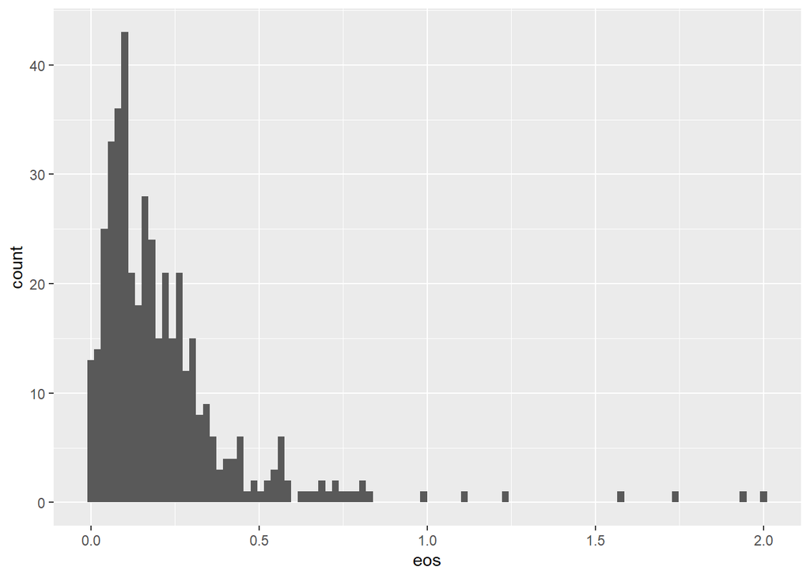

```r
ggplot(sph_dat_asthma) + geom_histogram(aes(eos), bins = 100)
```

```r
res_eos_expo_cont <- linear_res_fnc(expo = "eos",
                                    mets_list = feat_list,
                                    dat = "sph_dat_asthma",
                                    mets_info = "sph_mets_info",
                                    add_covar = " + Gender + bmi")
res_eos_expo_cont <- res_eos_expo_cont[, comparison := "eos_continous"] %>%
        setcolorder(., "comparison")
```

## 6.6. Continuous fev1

```r
sph_dat_asthma[, summary(fev1_prebd_pctpred)]
```

```
##    Min. 1st Qu.  Median    Mean 3rd Qu.    Max.    NA's
##   29.00   73.00   90.00   87.04  102.00  129.00     257
```

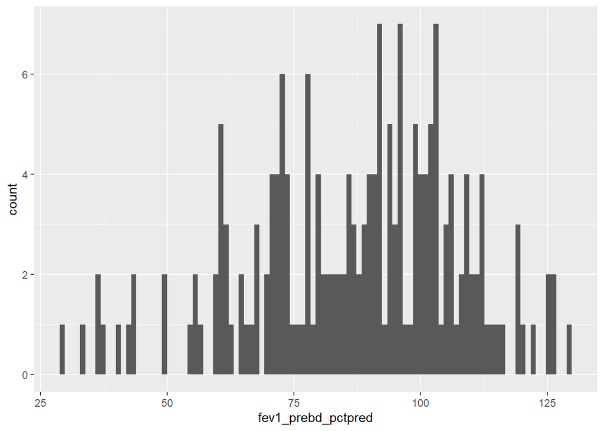

```r
ggplot(sph_dat_asthma) + geom_histogram(aes(fev1_prebd_pctpred), bins = 100)
```

```r
res_fev1_expo_cont <- linear_res_fnc(expo = "fev1_prebd_pctpred",
                                     mets_list = feat_list,
                                     dat = "sph_dat_asthma",
                                     mets_info = "sph_mets_info",
                                     add_covar = " + Gender + bmi")
res_fev1_expo_cont <- res_fev1_expo_cont[, comparison := "fev1_continous"] %>%
        setcolorder(., "comparison")

res_qt_asthmatics <- rbind(res_eos_expo_cont, res_fev1_expo_cont)
```

## 6.7. Continuous fvc

```r
sph_dat_asthma[, summary(fvc_prebd_pctpred)]
```

```
##    Min. 1st Qu.  Median    Mean 3rd Qu.    Max.    NA's
##    35.0    82.0    93.0    92.2   104.2   129.0     257
```

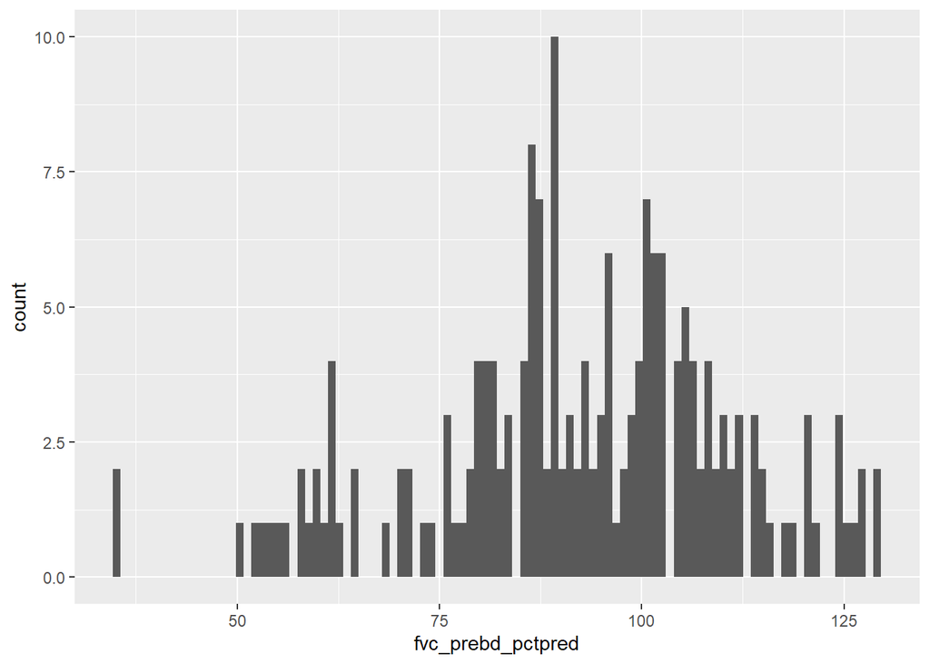

```r
ggplot(sph_dat_asthma) + geom_histogram(aes(fvc_prebd_pctpred), bins = 100)
```

```r
res_fvc_expo_cont <- linear_res_fnc(expo = "fvc_prebd_pctpred",
                                    mets_list = feat_list,
                                    dat = "sph_dat_asthma",
                                    mets_info = "sph_mets_info",
                                    add_covar = " + Gender + bmi")
res_fvc_expo_cont <- res_fvc_expo_cont[, comparison := "fvc_continous"] %>%
        setcolorder(., "comparison")

res_qt_asthmatics <- rbind(res_qt_asthmatics, res_fvc_expo_cont)


## Save results

saveRDS(res_qt_asthmatics, file = here(res_dir, "res_qt_asthmatics_sph.rds"))
```

## 6.8. Continuous neutrophil

```r
sph_dat_asthma[, summary(neut)]
```

```
##    Min. 1st Qu.  Median    Mean 3rd Qu.    Max.    NA's
##   0.510   3.400   4.280   4.831   5.710  15.550       8
```

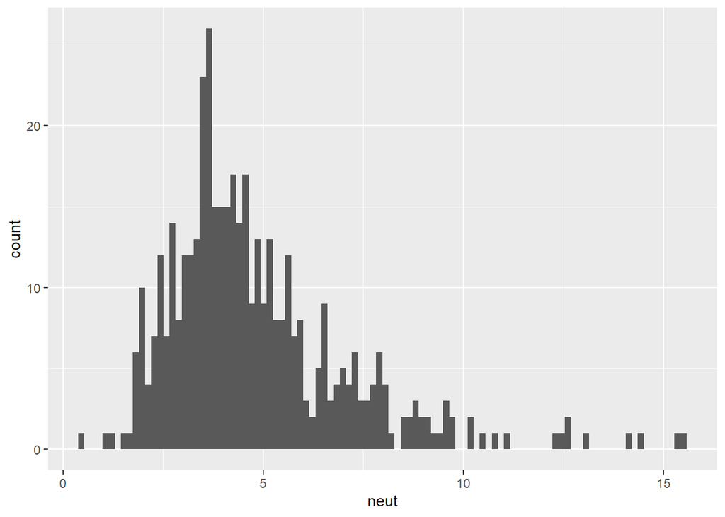

```r
ggplot(sph_dat_asthma) + geom_histogram(aes(neut), bins = 100)
```

```r
res_neut_expo_cont <- linear_res_fnc(expo = "neut",
                                     mets_list = feat_list,
                                     dat = "sph_dat_asthma",
                                     mets_info = "sph_mets_info",
                                     add_covar = " + Gender + bmi")
res_neut_expo_cont <- res_neut_expo_cont[, comparison := "neut_continous"] %>%
        setcolorder(., "comparison")

res_qt_asthmatics <- rbind(res_qt_asthmatics, res_neut_expo_cont)


## Save results

saveRDS(res_qt_asthmatics, file = here(res_dir, "res_qt_asthmatics_sph.rds"))
```